# Executive Summary

Executive Summary  
Data Science 2 with R (STAT 301-2)

Author

Chau Tran

Published

March 18, 2025

**Github Repo Link**

[Tran Chau’s Github Repo for Final Project](https://github.com/stat301-2-2025-winter/final-project-2-bunmam-ctrl.git)

## A. Introduction

This project develops a **predictive model** to classify home health agencies as `High` or `Low` quality based on key performance indicators such as patient outcomes, service effectiveness, and compliance with medical guidelines. Using **machine learning classification techniques**, the model analyzes agency characteristics, care delivery metrics, safety compliance, and financial performance to provide data-driven insights.

The [Home Health Care Agencies Dataset](https://data.cms.gov/provider-data/dataset/6jpm-sxkc#data-table) from the **Centers for Medicare & Medicaid Services (CMS)** serves as the foundation, offering comprehensive information on Medicare-registered providers. The target variable, `Quality of Patient Care Star Category`, is derived from CMS’s **1–5 star rating**, transformed into a binary classification.

This model has broad applications:

- *Patients & Families*
  - Identify high-quality providers for informed healthcare decisions.
- *Healthcare Providers*
  - Pinpoint areas for improvement to enhance care quality and regulatory compliance.
- *Policymakers & Regulators*
  - Monitor agencies, enforce quality standards, and promote accountability.

By increasing transparency and supporting data-driven decision-making, this model aims to improve healthcare quality and prevent failures in home health services.

## B. Data Overview

This predictive model applies machine learning classification techniques to evaluate home health agency quality, distinguishing between high- and low-quality agencies based on agency characteristics, patient outcomes, care effectiveness, and financial performance. By leveraging insights from **12,015 observations** and **35 variables** sourced from the [Home Health Care Agencies Dataset](https://data.cms.gov/provider-data/dataset/6jpm-sxkc#data-table), the model provides actionable intelligence for multiple stakeholders (Table 1). Patients and families can use it to identify top-performing agencies for better care outcomes, healthcare administrators can pinpoint areas for operational improvement, and policymakers can enforce quality standards more effectively.

Table 1: Summary Statistics of the Home Health Care Agencies Dataset.

| Metric | Number |
| --- | --- |
| Observation | 12015 |
| Variables | 35 |
| Numerical variables | 20 |
| Categorical variables | 8 |
| Missing values | 94765 |
| Missing values percentage | 23 |

The dataset includes agency service availability, timeliness of care, patient functional improvements, safety compliance, and financial performance metrics. To address **class imbalance** of the target variables, the original 1–5 star ratings were transformed into a **binary classification system**, with agencies categorized as `High` **(≥3.5 stars)** or `Low` **(<3.5 stars)**. Additionally, missing data—comprising **23% of the dataset**—was removed or imputed to mitigate bias in quality assessments (Table 1).

## C. Method

This study frames Quality of Patient Care Star Ratings as a **binary classification problem**, categorizing agencies as`High` **(≥3.5 stars)** or `Low` **(<3.5 stars)** to address class imbalance and improve model interpretability. The dataset is split **80/20** into training and testing sets, using **stratified sampling** to maintain proportional representation. To enhance model reliability, **10-fold cross-validation with 5 repeats** is applied, ensuring stable performance estimates and minimizing overfitting. This approach ensures the model effectively differentiates between high- and low-quality agencies while maintaining fairness and generalizability.

The following table summarizes the different models used for classification, detailing their descriptions and key hyperparameters that are fine-tuned to optimize performance.

Table 2: Overview of Machine Learning Models and Tuned Parameters for Quality Star Prediction

| Model Type | Description | Tuned Parameters |
| --- | --- | --- |
| Null Model | Baseline model that predicts the most frequent class, providing a reference point for evaluation | None |
| Logistic Regression | Simple, interpretable model that assumes a linear relationship between features and the response variable | None |
| Elastic Net | Regularized logistic regression that applies a penalty to prevent overfitting and improve generalization | `mixture` and `penalty` |
| K-Nearest Neighbors (KNN) | Distance-based model that classifies observations based on their proximity to training examples | `neighbors` |
| Random Forest | Ensemble model that reduces variance by combining multiple decision trees, capturing non-linear patterns | `mtry`, `trees`, and `min_n` |
| Boosted Tree | Gradient boosting model that iteratively improves weak learners to enhance predictive performance | `mtry`, `trees`, `min_n`, and `learn_rate` |

To ensure optimal model performance, two preprocessing recipes—basic and complex—are implemented, each with versions tailored for regression-based and tree-based models, addressing missing values, categorical encoding, and feature scaling.

Table 3: Preprocessing Steps for Regression-Based and Tree-Based Models Across Basic and Complex Recipes[^1]

<sup>1</sup> For more information about data splitting process, recipes building, and hyperparameter tuning, refer to **Method** in *Tran_Chau_final_report.html*

| **Preprocessing Step** | **Basic Recipe (Regression-Based Models)** | **Basic Recipe (Tree-Based Models)** | **Complex Recipe (Regression-Based Models)** | **Complex Recipe (Tree-Based Models)** |
| --- | --- | --- | --- | --- |
| **Removal of Non-Predictive Variables** | Exclude irrelevant features (`state`, `provider name`, etc.) | Same as regression-based models | Same as basic recipe | Same as basic recipe |
| **Filtering Out Zero-Variance Predictors** | Remove features with no variability | Remove features with no variability | Same as basic recipe | Same as basic recipe |
| **Handling Missing Data (Numerical)** | Impute missing values using **mean** | Impute missing values using **mean** | Same as basic recipe | Same as basic recipe |
| **Handling Missing Data (Categorical)** | Impute missing values using **mode** | Impute missing values using **mode** | Same as basic recipe | Same as basic recipe |
| **Encoding Categorical Variables** | **Dummy encoding** (drop one reference category) | **One-hot encoding** (retain all levels) | Same as basic recipe | Same as basic recipe |
| **Feature Scaling** | Normalize numerical features for standardization | Standardization optional for consistency | Same as basic recipe | Same as basic recipe |
| **Handling Skewed Distributions** | Not applied | Not applied | **Log10 transformation** for extremely skewed features (`num_episodes`) | **Log10 transformation** for extremely skewed features (`num_episodes`) |
| **Incorporating Interaction Terms** | Not applied | Not applied | Identify interactions via **scatterplot analysis** and add significant terms | Not applied (tree models inherently capture interactions) |

`ROC-AUC` is the primary metric used to evaluate model performance, as it ensures both accurate classification and strong discriminative ability. `Accuracy` provides a measure of correctly classified agencies, making it a useful indicator after dataset balancing. However, **`ROC-AUC` is prioritized** because it evaluates the model’s ability to distinguish between high- and low-quality agencies across various probability thresholds, ensuring robustness in real-world decision-making. By emphasizing these metrics, the final model is chosen for its ability to achieve both overall correctness and effective class separation.

## D. Model Selection

According to Table 4, the *boosted tree model with complex recipes* emerged as the best-performing model, achieving an `accuracy` of **0.979** and, more importantly, an `ROC-AUC` of **0.998**, demonstrating exceptional predictive reliability. With an `accuracy` of **97.9%**, the model correctly classifies healthcare agencies with minimal errors, ensuring precise decision-making in policy planning and patient referrals. Its `ROC-AUC` of **0.998** highlights its near-perfect ability to distinguish between high- and low-quality agencies, minimizing misclassification risks. Additionally, its small standard error values ($6.09 × 10^{-4}$ for `accuracy` and $8.96 × 10^{-5}$ for `ROC-AUC`) confirm its stability across different data samples. The model’s superior performance is attributed to its ability to capture complex, nonlinear relationships, optimized through **2,000 trees** and fine-tuned hyperparameters (`mtry` = 5, `min_n` = 2, and `learn_rate` = 0.0541 according to Table 5).[^2]

<sup>2</sup> For more analysis on different models performing, refer to **Model Building** in *Tran_Chau_final_report.html*

Table 4: Performance comparison of different predictive models using the complex recipe.

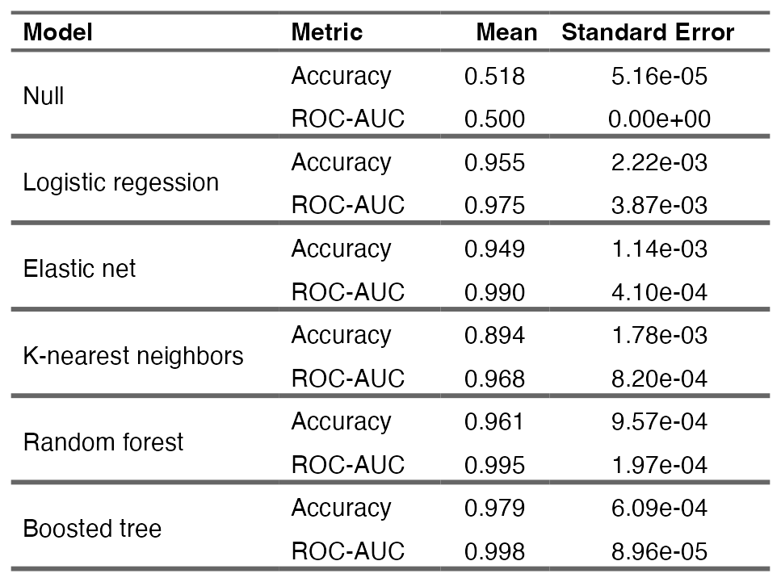

Table 5: Optimized Parameters for the Boosted Tree Model.

| trees | mtry | min_n | learn_rate |
| --- | --- | --- | --- |
| 2000 | 5 | 2 | 0.0541 |

## E. Final Model Analysis

The final *boosted tree model* was evaluated on the testing dataset to determine its effectiveness in distinguishing between high- and low-quality healthcare agencies. As shown in Table 6, the model demonstrated **exceptional predictive performance**, achieving an `accuracy` of **0.976**, meaning it correctly classified **97.6%** of agencies. This high accuracy indicates that the model consistently makes correct predictions, ensuring that healthcare agencies are categorized with minimal errors.

Table 6: Performance metrics of the final boosted tree model, evaluated using Accuracy and ROC-AUC

| Performance Metric | Estimate Value |
| --- | --- |
| Accuracy | 0.976 |
| ROC-AUC | 0.998 |

Moreover, the model’s `ROC-AUC` of **0.998** highlights its outstanding ability to differentiate between high- and low-quality agencies across a range of decision thresholds. This means the model reliably assigns higher probability scores to high-quality agencies and lower scores to low-quality ones, minimizing both **false positives** (misclassifying low-quality agencies as high-quality) and **false negatives** (misclassifying high-quality agencies as low-quality). In real-world applications, such a high `ROC-AUC` is critical, as it ensures that decision-makers—such as healthcare regulators, policymakers, and patients—can trust the model’s predictions when evaluating agency quality.[^3]

<sup>3</sup> For more analysis on the final model’s performance on the testing set, refer to **Final Model Analysis** in *Tran_Chau_final_report.html*

## F. Conclusions

The *boosted tree model* outperformed regression-based approaches, achieving high `accuracy` **(0.976)** and near-perfect `ROC-AUC` **(0.998)**, making it a reliable tool for classifying healthcare agencies. However, challenges remain in interpretability and practical application.

## G. Future Directions

1. Expand to multiclass classification for nuanced quality assessment.
2. Improve interpretability with SHAP[^4] and feature importance.
3. Refine feature engineering by selecting only meaningful interactions.
4. Optimize decision thresholds for real-world policy applications.

<sup>4</sup> [A Unified Approach to Interpreting Model Predictions](https://doi.org/10.48550/arXiv.1705.07874)

<sup>5</sup> For more elaboration on future direction, refer to **Section B** of *Conclusion* in *Tran_Chau_final_report.html*

Enhancing these areas will improve both predictive accuracy and practical usability, making the model more effective for healthcare decision-making.[^5]

## H. Use of Generative AI

I used ChatGPT to improve sentence flow, check grammar, and make my writing more concise.